# Data 624 Homework 6: ARIMA

```r
forecast(fit, h=3)
```

```
##      Point Forecast    Lo 80    Hi 80    Lo 95    Hi 95
## 2005       2.595506 2.320177 2.870835 2.174427 3.016585
## 2006       2.594992 2.221624 2.968359 2.023976 3.166007
## 2007       2.595035 2.143387 3.046682 1.904300 3.285770
```

```r
f1 = wmurders[55] + (-0.0841 * (wmurders[55] - wmurders[54])) - 0.0000025
f2 = f1 + (-0.0841 * (f1 - wmurders[55]))
f3 = f2 + (-0.0841 * (f2 - f1))
print(paste('forecast 1:', f1))
```

```
## [1] "forecast 1: 2.5955066804"
```

```r
print(paste('forecast 2:', f2))
```

```
## [1] "forecast 2: 2.59499167887836"
```

```r
print(paste('forecast 3:', f3))
```

```
## [1] "forecast 3: 2.59503499050633"
```

```r
for(i in 2:51){
    theta = 1
    test <- wmurders %>% diff()
    test[i] <- test[i - 1] + theta*e[i-1] + e[i]}
test
```

```
## Time Series:
## Start = 1951
## End = 2004
## Frequency = 1
##  [1] -0.066051  0.010941 -0.078785  0.034196 -0.096699  0.145162 -0.055508
##  [8]  0.093885  0.081643  0.081254  0.001387  0.048453 -0.047440  0.139087
## [15]  0.123834  0.300088  0.288182 -0.074626  0.104202  0.184722  0.343738
## [22] -0.065378  0.565260  0.000579 -0.094974 -0.412076  0.130620 -0.096573
## [29]  0.182569  0.166352 -0.139356 -0.082214 -0.359198  0.040682 -0.006997
## [36]  0.204758  0.044996  0.035790 -0.066893  0.074951  0.296692 -0.300084
## [43]  0.247114 -0.398660 -0.076133 -0.358104 -0.275239 -0.109680 -0.105621
## [50] -0.229222 -2.275403 -0.506770 -0.135470 -0.072844
```

6. Create a plot of the series with forecasts and prediction intervals for the next three periods shown.

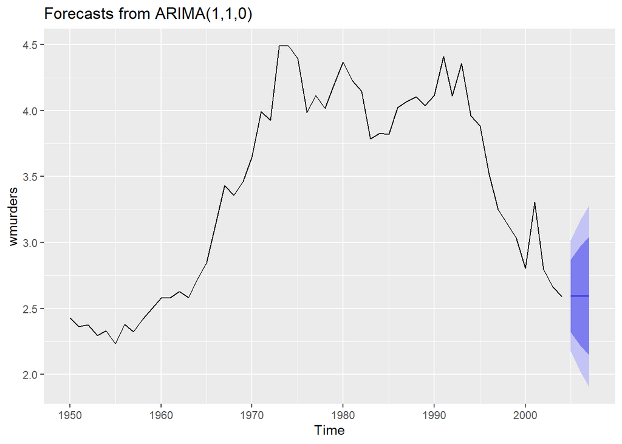

```r
autoplot(forecast(fit, h=3))
```

7. Does auto.arima() give the same model you have chosen? If not, which model do you think is better?

Auto.arima does not give the same model as my selection. My model projects a constant rate of women’s deaths, while the auto arima model projects decreasing rates over the next three years.

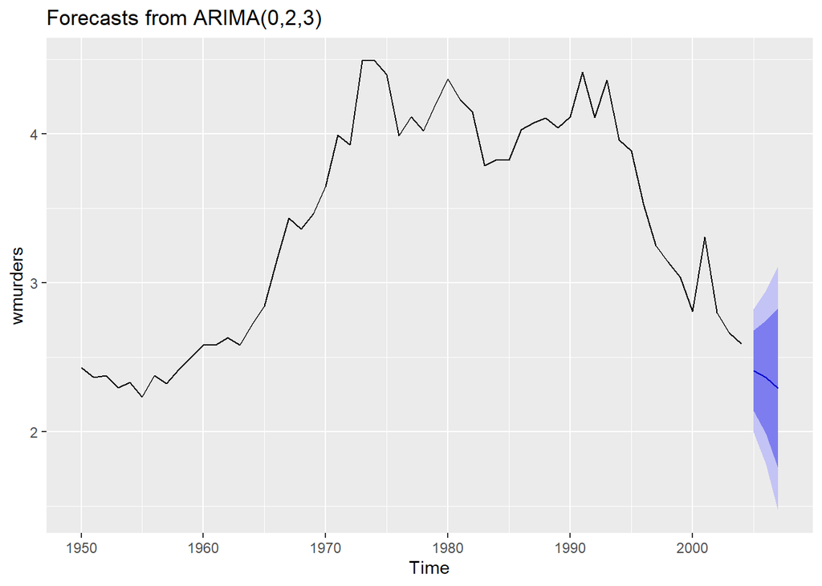

```r
fit_auto <- auto.arima(wmurders, stepwise=FALSE, approximation=FALSE)
autoplot(forecast(fit_auto,3))
```

```r
fit
```

```
## Series: wmurders
## ARIMA(1,1,0)
##
## Coefficients:
##           ar1
##       -0.0841
## s.e.   0.1346
##
## sigma^2 estimated as 0.04616:  log likelihood=6.92
## AIC=-9.85   AICc=-9.61   BIC=-5.87
```

```r
fit_auto
```

```
## Series: wmurders
## ARIMA(0,2,3)
##
## Coefficients:
##           ma1     ma2      ma3
##       -1.0154  0.4324  -0.3217
## s.e.   0.1282  0.2278   0.1737
##
## sigma^2 estimated as 0.04475:  log likelihood=7.77
## AIC=-7.54   AICc=-6.7   BIC=0.35
```